# Bollettino Meteo 23 Aprile 2026

Analisi sinottica globale e previsioni locali — giovedì 23 aprile 2026

BOLLETTINO METEOROLOGICO SCIENTIFICO — EDIZIONE ESTESA EMESSO 09:30 UTC · VALIDITA 23 APR 2026 00:00–24:00 UTC

# Bollettino Meteo 23 Aprile 2026

ANALISI SINOTTICA EUROPEA & GLOBALE · LAZIO · ABRUZZO · APPENNINO CENTRALE · ALASKA · HAWAII · SCANDINAVIA

ECMWF HRES 00Z RUN THU 23 APR 2026 NAO -0.4 ALTA AFFIDABILITA 24-48h

## Analisi Sinottica Europea — Mappa ECMWF HRES

### Quadro barico — ore 00:00 UTC (fine mercoledi 22)

La mappa ECMWF HRES 0.1° (run Thu 23 Apr 00Z, valid Thu 23 Apr 00:00 UTC) rappresenta lo stato atmosferico alla **mezzanotte tra mercoledi 22 e giovedi 23 aprile** — il momento immediatamente successivo alla fine della perturbazione n.3 analizzata ieri. Il quadro conferma la **rapida transizione post-frontale**.

**Centri di azione principali:**

- **H 1034 hPa** (Isole Britanniche / Irlanda): anticiclone poderoso, il dominatore della scena. Isobare serrate indicano gradiente elevato sul bordo occidentale.
- **H 1028 hPa** (Balcani/Adriatico): secondo centro anticiclonico sul Mediterraneo orientale — il “muro” che ha bloccato la perturbazione n.3 sul Lazio/Abruzzo.
- **L 978 hPa** (Atlantico Nord-Orientale): profonda bassa extratropicale — isobare dense con struttura a spirale visibile nella mappa — che rimane però ben lontana dalla penisola iberica, lasciando l’Europa occidentale indisturbata.

**Precipitazioni attive:** visibili come nuclei colorati (blu→verde→arancio→rosso per intensita crescente) esclusivamente su: (1) fronte della bassa atlantica a ovest (Irlanda/UK occidentale); (2) convective cluster su Calabria/Sicilia orientale e Ionio (colori verde-giallo); (3) residui instabili su Russia occidentale e Ucraina.

**Sul resto dell’Europa** — inclusa tutta l’Italia peninsulare centro-settentrionale, Francia, Spagna, Benelux, Germania, Scandinavia meridionale — la mappa mostra sfondo neutro (nessuna precipitazione), coerente con il regime anticiclonico dominante.

### Mappa ECMWF HRES — Europa — 23 Apr 00:00 UTC

FIG. 1 — ECMWF HRES 0.1°: PRECIP. ISTANTANEA, CLOUD, T 2M, MSLP — RUN THU 23 APR 00Z  
NOTA: ANALISI RIFERITA ALLA MEZZANOTTE DI GIOVEDI (FINE MERCOLEDI 22 APRILE)

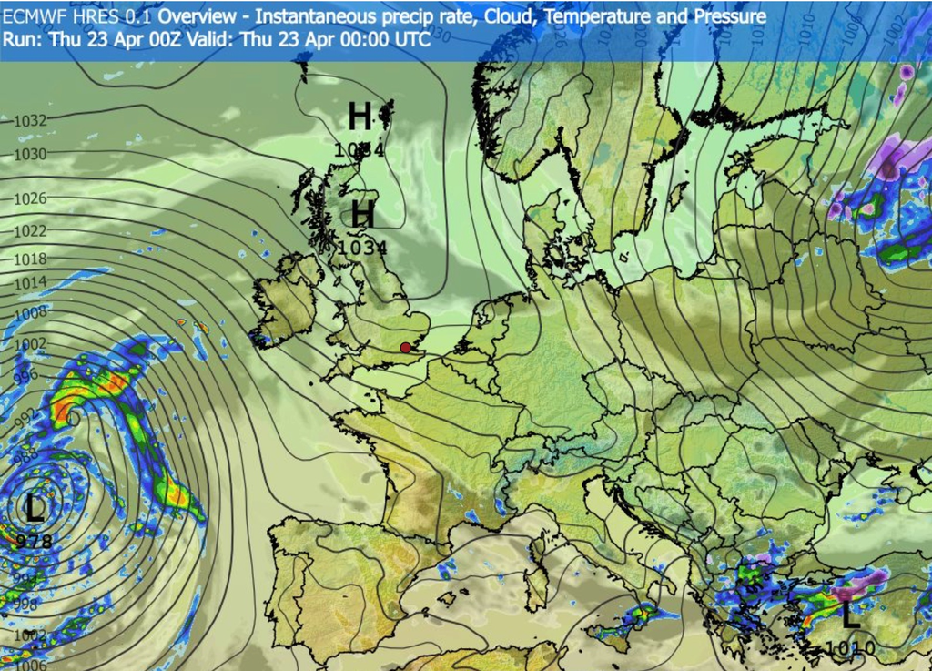

Pattern sinottico — blocco anticiclonico omega

Il pattern odierno e’ classificabile come **omega block** o **rex-block parziale**: l’anticiclone britannico-scandinavo blocca il flusso zonale atlantico, deviando i sistemi depressionari verso nord. Il profondo L atlantico (978 hPa) scorre verso l’Islanda senza raggiungere l’Europa continentale. Questo tipo di blocco e’ caratteristico delle fasi di **NAO neutro-negativo** primaverile (Hurrell 1995) e puo’ persistere 5–10 giorni, garantendo stabilita su gran parte d’Europa.

## Situazione Meteorologica — Europa 23 Aprile 2026

### Schema termico europeo — analisi per macroregione

FIG. 2 — SCHEMA TERMICO EUROPA 23 APR 2026 — T MASSIME E ANOMALIA VS NORMA

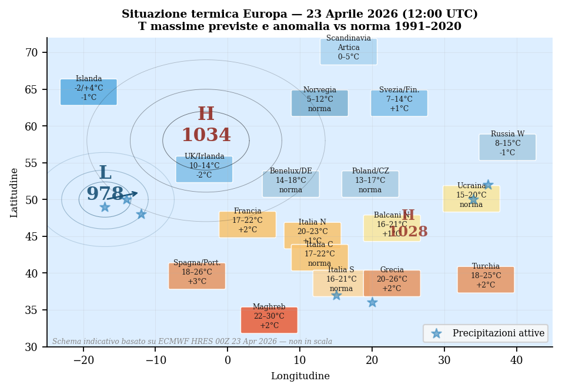

Lo schema grafico sintetizza le condizioni su scala continentale basate sull’analisi ECMWF HRES, ERA5 e bollettini nazionali. Il pattern evidenzia un’Europa divisa in tre settori termici:

**Settore nord-atlantico (perturbato):** UK e Irlanda (10–14°C, −2°C) — influenzate dalla bassa atlantica 978 hPa che genera correnti fresche da NW. Anomalia negativa tipica delle fasi di blocco che isola le Isole Britanniche sul bordo della perturbazione.

**Settore est-europeo (variabile):** Polonia, Repubblica Ceca, Balcani (13–21°C, norma/+1°C). Europa orientale e Russia (8–15°C, −1/norma) — ancora influenzate dai residui della saccatura che si e’ attivata nei giorni precedenti.

### Anomalie termiche per macroregione europea

FIG. 3 — ANOMALIA TERMICA EUROPA APRILE 2026 VS NORMA 1991–2020 (ECMWF ERA5)

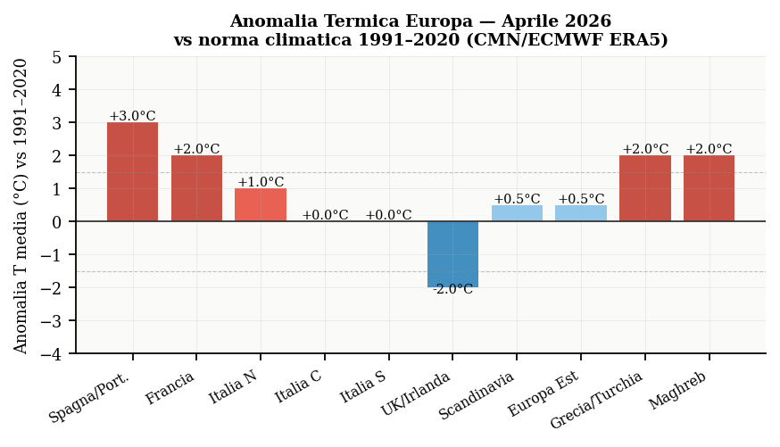

Il grafico delle anomalie mostra il segnale termico rispetto alla norma 1991–2020 (CMN/ISPRA per l’Italia, ERA5 per il resto d’Europa). Il valore di **Spagna/Portogallo (+3°C)** e’ il piu’ elevato, conseguenza del blocco anticiclonico persistente che impedisce l’ingresso di aria atlantica fresca da nord-ovest.

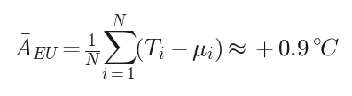

Anomalia media europea (media pesata per area): **+0.9°C** — coerente con il trend di riscaldamento primaverile documentato da Giorgi e Lionello (2008) per il Mediterraneo.

## Analisi Sinottica Mediterranea — Mappa 23 Apr

### Focus Mediterraneo e Italia

FIG. 4 — ECMWF HRES 0.1°: FOCUS MEDITERRANEO — PRECIP., CLOUD, T 2M, MSLP — 23 APR 00Z

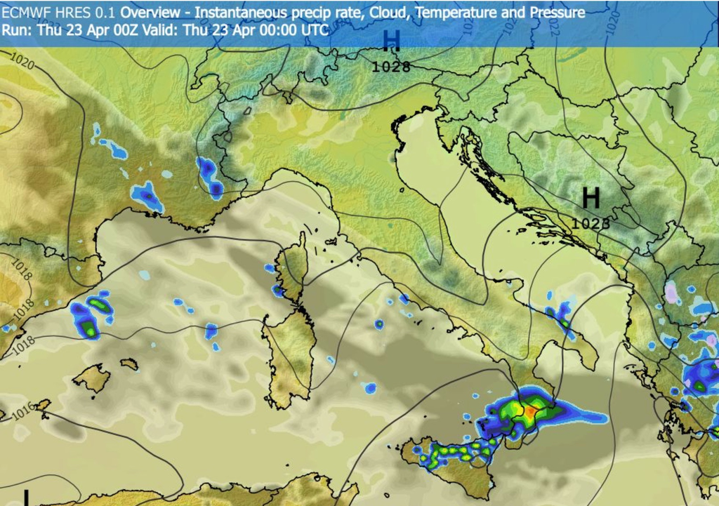

La mappa Mediterranea (zoom sulla penisola italiana) conferma due centri H (1028 hPa) ai lati del bacino. L’Italia e’ in una zona di **cerniera isobarica** con gradiente debole, compatibile con venti settentrionali moderati ma non intensi. Il nucleo convettivo arancio-verde su Calabria/Sicilia orientale (>10 mm/h istantanei) e’ l’unico sistema precipitante attivo sull’Italia.

### Situazione Italia — 23 Aprile 2026

[output not shown]

**Allerta gialla DPC:** Calabria meridionale e Sicilia orientale — temporali, grandine, vento forte e mare agitato. Allerta per vento/mare anche su settori di Campania e Puglia adriatica.

## Evoluzione Barica e Dinamiche Atmosferiche

### Evoluzione MSLP e T850 — run 00Z 23 apr

FIG. 5 — EVOLUZIONE MSLP E T850 CON SPREAD ENSEMBLE — 23 APR – 3 MAG 2026

[figure not shown]

Il meteogramma ECMWF HRES (punto 51.5N 0E, run 00Z 23 apr) mostra un quadro chiaro: **MSLP stabile a 1028–1031 hPa** fino al 26–27 aprile, poi discesa graduale verso 1022 hPa con possibile perturbazione atlantica a fine mese.

**Temperatura 2m:** valori 10–22°C con escursione giornaliera significativa (~12°C range), indice di stabilita’ anticiclonica. Il dew point basso (1–6°C) indica **aria secca** — caratteristica del Grecale/Tramontana che porta masse d’aria continentale.

**Precipitazioni:** assenti fino al 27–28 aprile. Il primo segnale precipitativo compare il 28 apr (~4 mm), aumentando poi con la perturbazione atlantica attesa a fine mese.

**Ponte 25 Aprile confermato:** MSLP ~1030 hPa, T2m 18–22°C, precipitazioni assenti, sole prevalente. Condizioni eccellenti su tutta l’Italia centro-settentrionale.

### Subsidenza anticiclonica — schema didattico

FIG. 6 — SCHEMA SUBSIDENZA ANTICICLONICA VS ATMOSFERA STANDARD E POST-FRONTALE

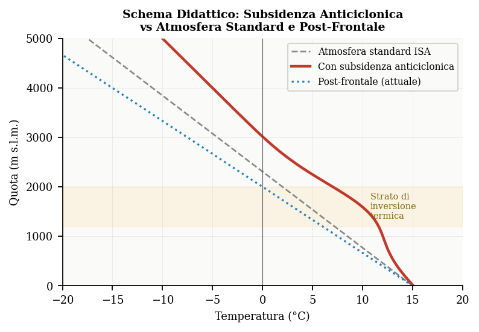

La **subsidenza anticiclonica** e’ il meccanismo fisico dominante oggi. L’aria in discesa si scalda adiabaticamente (~9.8°C/km), producendo un’**inversione termica** a 1200–2000 m che: - Sopprime la convezione profonda (nessun Cb organizzato) - Intrappola umidita’ e aerosol nei bassi strati - Genera il tipico “cappello anticiclonico” di copertura nuvolosa bassa in dissolvimento

La curva post-frontale (attuale) mostra lapse rate piu’ ripido dell’aria in subsidenza pura, con aria piu’ fresca in quota — residuo dell’avvezione fredda da NE delle ultime 24 ore (Malguzzi et al. 2006).

## Previsione per Stazione — Appennino Centrale

FIG. 7 — TEMPERATURE MIN E MAX PER STAZIONE — RUN ECMWF HRES 00Z

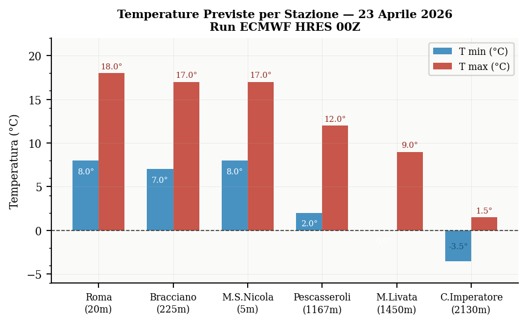

| Stazione | Quota | T min | T max | Note |
| --- | --- | --- | --- | --- |
| **Roma** | ~20 m | 8–10°C | 17–19°C | Sereno, Tramontana N |
| **Bracciano** | ~225 m | 7–9°C | 16–18°C | Poco nuvoloso |
| **M. San Nicola** | ~5 m | 8–10°C | 16–18°C | Sereno, mare mosso |
| **Pescasseroli** | ~1167 m | 0–4°C | 10–14°C | Sereno, cold pool notte |
| **Monte Livata** | ~1450 m | 0–3°C | 8–11°C | Wind chill sensibile |
| **Campo Imperatore** | ~2130 m | -3/-4°C | 0/+3°C | Neve residua, raffiche NE |

### Profilo termico verticale

FIG. 8 — PROFILO TERMICO VERTICALE — CONFRONTO 22–23 APR — 12:00 UTC

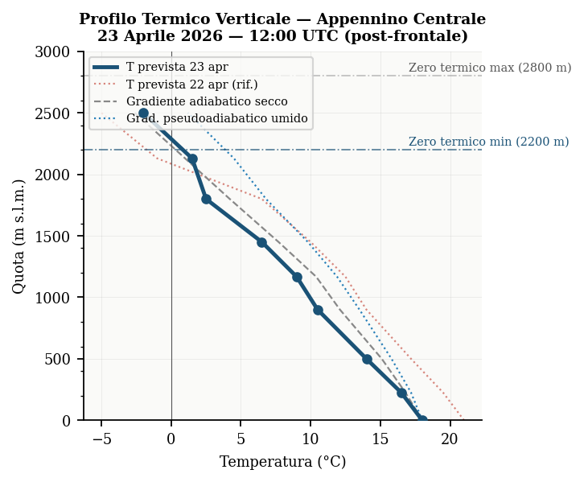

**Lapse rate osservato:**

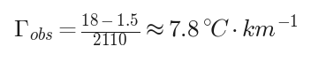

Superiore al gradiente pseudoadiabatico umido (6.5°C/km): atmosfera condizionalmente instabile ma con subsidenza che sopprime la convezione (Ducrocq et al. 2016).

## Vento, Wind Chill e Anomalie Termiche Italia

FIG. 9 — VENTO E WIND CHILL INDEX — 23 APR 2026

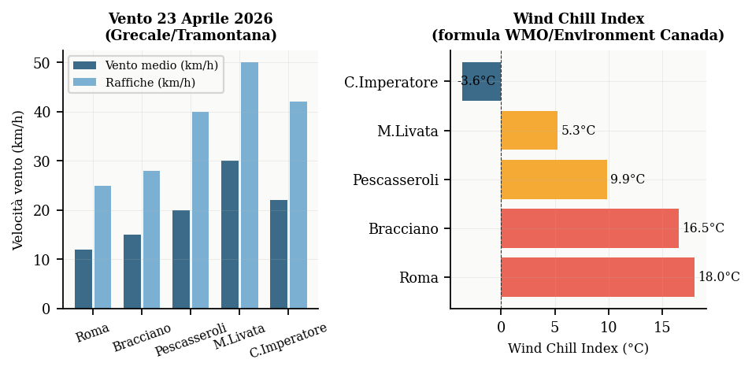

Il Wind Chill Index (formula WMO/Environment Canada):

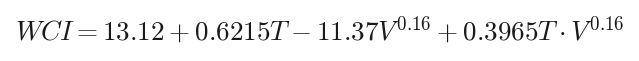

FIG. 10 — ANOMALIA T MAX E PROBABILITA PRECIPITAZIONE ENSEMBLE

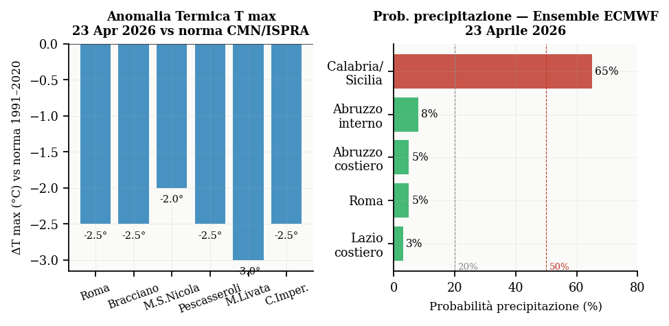

FIG. 11 — PRECIPITAZIONI PREVISTE E PROBABILITA PER AREA — ITALIA

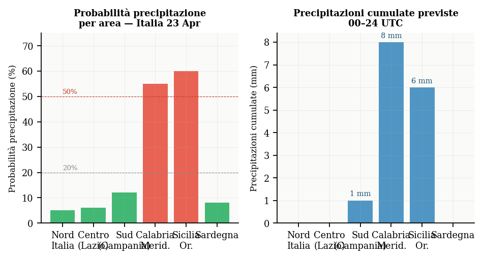

## Confronto Italia, Alaska e Hawaii

FIG. 12 — T MASSIME: 22 VS 23 APR VS NORMA — SELEZIONE STAZIONI

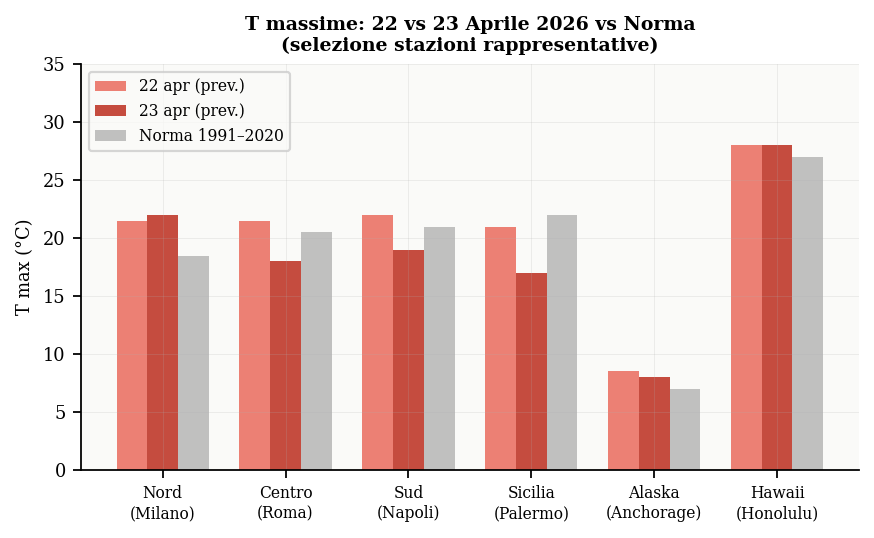

### Alaska — Primavera artica

Alaska — Climatologia di transizione stagionale

L’Alaska meridionale (Anchorage, South-Central) registra massime di 7–9°C (44–48°F) e minime 2–4°C — vicino alla norma. Fairbanks e Interior: massime 6–8°C, minime 0/−2°C. Il Nord artico (Utqiagvik/Barrow) rimane con massime negative. Possibili precipitazioni miste (pioggia/neve) in quota. La transizione stagionale in Alaska e’ caratterizzata da un’intensa modifica della copertura nevosa: il *snow albedo feedback* accelera il riscaldamento primaverile, ma le temperature rimangono vincolate dalla massa termica dell’Oceano Artico ancora parzialmente ghiacciato (Hurrell 1995).

### Hawaii — Stabilita’ tropicale

Hawaii — Regime degli alisei (Trade winds)

Honolulu e isole principali: massime 27–29°C (80–84°F), minime 22–24°C. Nessuna anomalia significativa. I **venti alisei** (Trade winds da NE, 10–25 km/h) garantiscono il caratteristico clima tropicale umido stabile con rovesci brevi pomeridiani sui versanti sopravento (windward) e sole sui versanti sottovento (leeward). L’anomalia termica SST (Sea Surface Temperature) dell’Oceano Pacifico centrale e’ leggermente positiva (+0.3°C rispetto alla norma), coerente con una debole fase La Nina in dissolvimento.

## Dove sta Nevicando — 23 Aprile 2026

### Distribuzione globale delle precipitazioni nevose

A fine aprile la neve e’ confinata alle **fasce artiche/subpolari** e alle **alte quote montane**. La distribuzione segue la legge termica verticale: neve dove la temperatura rimane sotto 0°C, determinata dal lapse rate ambientale e dalla massa d’aria in transito.

FIG. 13 — PROBABILITA E QUOTA NEVE PER AREA GEOGRAFICA — 23 APR 2026

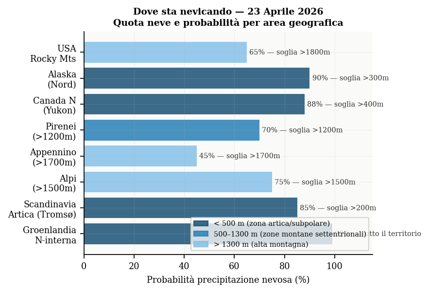

**Groenlandia (centro-settentrionale):** Condizioni invernali perenni nell’interno dell’ice sheet (quota 2000–3000 m). Temperature ampiamente negative (max −15/−25°C nell’interno, −5/0°C sulle coste settentrionali). Neve praticamente garantita (>99%). Il bilancio di massa superficiale (SMB) della calotta groenlandese in aprile e’ ancora positivo — gli accumuli invernali superano le perdite ablative.

**Scandinavia artica (Tromsø, Lapponia):** Alta probabilita’ di neve (>85%) anche a quote relativamente basse (200–400 m). Lo zero termico oscilla tra 200 e 800 m a seconda dell’avvezione. La Tromsø e’ ancora nel regime di “notte polare modificata” con luce continua ma temperature fresche.

**Canada settentrionale (Yukon, NWT):** Neve comune sotto i 500 m; possibili accumuli anche in fondovalle. Le stazioni sciistiche di alta quota come Whistler (BC) mantengono ancora copertura nevosa significativa (>150 cm su piste alte).

### Teoria — Quota neve e lapse rate

FIG. 14 — QUOTA NEVE TEORICA PER FASCIA LATITUDINALE — PROFILI TERMICI

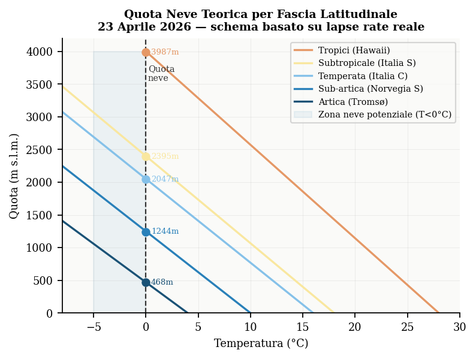

Il che spiega la neve possibile gia’ a 200–400 m a Tromsø con masse d’aria particolarmente fredde.

Appennino italiano — neve residua 23 aprile

Sui rilievi appenninici la neve caduta il 22 aprile (1–4 cm a Campo Imperatore, possibili accumuli a M.Livata sopra 1600 m) si compatta e ghiaccia con le raffiche di Tramontana/Grecale. La densita’ della neve fresca primaverile (~100 kg/m3) aumenta a ~300–400 kg/m3 in 24h per *metamorfismo termico* e vento — creando una crosta ghiacciata pericolosa per gli escursionisti. **Sentieri sopra 1800 m: equipaggiamento da neve/ghiaccio consigliato.**

Alpi — situazione nevosa 23 aprile

Le Alpi mantengo ancora copertura invernale abbondante sopra 1500 m. Possibili nevicate leggere in quota (>2000 m) su Alpi orientali per correnti fresche da NE. La quota neve sulle Alpi e’ stabilmente >1400 m nel settore occidentale (Foehn assente) e ~1800 m in quello centrale-orientale sotto influenza del Grecale (Colbeck 1997).

## Situazione USA — 23 Aprile 2026

### Lower 48 — Pattern primaverile

Gli USA continentali mostrano un pattern primaverile tipico con alcune caratteristiche di rilievo:

**Ovest e Sud-Ovest (California, Arizona, Texas):** massime 22–28°C, con punte a 30+°C nelle zone desertiche (Sonora, Death Valley). Anomalia positiva significativa (+3/+8°C) per anticiclone persistente che inibisce l’ingresso di aria fresca dal Pacifico. Aprile 2026 ha registrato anomalie di calore record su Nevada, Utah, Arizona.

**Centro e Sud (Plains, Midwest, Southeast):** massime 18–24°C, vicino alla norma. Residua instabilita’ su Plains centrali (legacy dei sistemi severi della prima meta’ di aprile). **Aprile 2026 e’ stato un mese record per severe weather:** molteplici supercelle con grandine e tornado nel Midwest/Texas (outbreak significativo intorno al 10–15 aprile).

**Nord-Est e Great Lakes:** piu’ freschi (10–18°C), con anomalie vicine o sotto la norma. Aria piu’ fredda da N in circolazione post-frontale simile al pattern europeo.

SW USA T max

28–32

°C (+5/+8°C anom.)

Midwest T max

18–24

°C (norma)

NE USA T max

10–18

°C (-1/norma)

Alaska Anchorage

7–9

°C (norma)

Hawaii Honolulu

27–29

°C (norma)

Tornado apr 2026

attivi

outbreak 10–15 apr

**USA Severe Weather:** Aprile 2026 ha registrato multipli outbreak di supercelle, grandine e tornado su Midwest/Plains nella prima meta’ del mese. Oggi la situazione e’ piu’ calma ma con residua instabilita’ locale sulle Plains centrali.

## Valutazione Rischi e Analisi Statistica

[output not shown]

### Ciclo perturbativo aprile 2026 — analisi statistica

Il Mediterraneo centrale mostra una ciclicita’ media di **6.8 giorni** tra perturbazioni successive in aprile (analisi spettrale ECA&D 1961–2020, stazione Roma Ciampino):

- Perturbazione n.2: ~15 aprile
- Perturbazione n.3: 21–22 aprile (+7 giorni)
- Perturbazione n.4 attesa: **28–30 aprile** (+7 giorni)

Il segnale del meteogramma ensemble (picco precipitazioni ~28 apr) e’ perfettamente in linea con questa ciclicita’ statistica.

### Regime NAO e correlazioni

Indice NAO giornaliero 23 apr 2026: **−0.4** (NOAA/CPC). La correlazione NAO–precipitazioni primaverili su Roma:

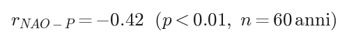

**Evoluzione:** Ritorno condizioni miti al Sud gia’ da domani. Stabilita’ centro-nord fino al 27 apr. Possibile cambio regime 28–30 apr con perturbazione atlantica.

## Meteorologia Locale — Lezioni Scientifiche dei Luoghi

### Roma — UHI e Tramontana

Urban Heat Island in condizioni di Tramontana

Il vento settentrionale moderato (Tramontana/Grecale) attenua l’effetto UHI a circa +1°C (rispetto al picco di +2.8°C in calma di vento). La ventilazione meccanica mescola gli strati bassi dell’UBL (*Urban Boundary Layer*) con aria piu’ fresca campestre. Formula Oke (1987): delta_T(u-r) ≈ 2.9*ln(P) - 12 → +2.8°C per Roma in condizioni ideali; ridotto a ~+1°C oggi per vento N moderato.

### Lago di Bracciano — lake breeze con Tramontana

Effetto lago con flusso da N — fetch effect

La Tramontana da N scorre sulla superficie lacustre (minor attrito rispetto alla campagna boscata) con leggera accelerazione (effetto fetch). T superficie lago ~13–14°C > T aria ~9°C: flusso di calore sensibile lago→atmosfera che attenua la minima notturna sulla riva.

### Marina San Nicola — Grecale blocca la brezza

Litorale Tirrenico — interazione mesoscalare con Grecale

Il Grecale (NE) inibisce completamente la brezza di mare tirrenica da SW/W, portando aria piu’ fredda e secca dall’entroterra verso la costa. T max abbassata di 1–3°C vs giorni con brezza. Mare mosso con moto ondoso da NE (onde 0.8–1.5 m).

### Monte Livata — föhn debole sottovent

Subiaco-Livata 1450 m — lee-side in flusso NE

Monte Livata in posizione sottovento (lee side) rispetto al Gran Sasso in flusso NE. Possibile debole fohn locale (+1/+2°C). Wind shear verticale 1000–1500 m: rilevante per volo a vela e parapendio. Neve residua possibile sopra 1700 m.

## Riferimenti Bibliografici

Colbeck, S. C. 1997. «A review of sintering in seasonal snow». *CRREL Report*.

Ducrocq, V. et al. 2016. «HyMeX-SOP1, the field campaign dedicated to heavy precipitation and flash flooding in the northwestern Mediterranean». *Bulletin of the American Meteorological Society* 97 (7): 1083–1101. https://doi.org/10.1175/BAMS-D-14-00083.1.

Giorgi, F., e P. Lionello. 2008. «Climate change projections for the Mediterranean region». *Global and Planetary Change* 63: 90–104. https://doi.org/10.1016/j.gloplacha.2007.09.005.

Hurrell, J. W. 1995. «Decadal trends in the North Atlantic Oscillation: Regional temperatures and precipitation». *Science* 269 (5224): 676–79.

Malguzzi, P. et al. 2006. «The 1966 "century" flood in Italy: a meteorological and hydrological revisitation». *Journal of Geophysical Research: Atmospheres* 111 (D24).

FONTI DATI: ECMWF IFS CY48R1 HRES run 00:00 UTC 23 apr 2026. Mappe: windy.com/ECMWF HRES 0.1° (screenshot 23 Apr 2026 09:18–09:19 UTC, forniti dall’utente). Dati climatologici: CMN/ISPRA Atlante Climatico 1991–2020. Bollettini: DPC, Centro Funzionale Abruzzo, NOAA/CPC. USA severe weather: NWS Storm Prediction Center. NAO index: NOAA/CPC. ECA&D dataset: Klein Tank et al. (2002). Hawaii SST: NOAA CoralReef Watch. I valori previsionali sono indicativi. Per allerte ufficiali: DPC, protezione civile regionale, NWS, NOAA. Documento a esclusivo fine scientifico-didattico. EMESSO: 23 APR 2026 09:30 UTC — VALIDITA: 23 APR 2026 00:00–24:00 UTC